# Ensemble Techniques Alt. project-Parkinson’s Diagnosis

Data Attribute Information: • name - ASCII subject name and recording number • MDVP:Fo(Hz) - Average vocal fundamental frequency • MDVP:Fhi(Hz) - Maximum vocal fundamental frequency • MDVP:Flo(Hz) - Minimum vocal fundamental frequency • MDVP:Jitter(%),MDVP:Jitter(Abs),MDVP:RAP,MDVP:PPQ,Jitter:DDP–Severalmeasures of variation in fundamental frequency • MDVP:Shimmer,MDVP:Shimmer(dB),Shimmer:APQ3,Shimmer:APQ5,MDVP:APQ,Shimm er:DDA - Several measures of variation in amplitude • NHR,HNR-Two measures of ratio of noise to tonal components in the voice. • RPDE,D2- Two nonlinear dynamical complexity measures • DFA - Signal fractal scaling exponent • spread1,spread2,PPE-Three non-linear measures of fundamental frequency variation. • status-Health status of the subject(one) - Parkinson's,(zero) -healthy.

```python
import warnings
warnings.filterwarnings('ignore')

import numpy as np
import pandas as pd
import seaborn as sns
import matplotlib.pyplot as plt
%matplotlib inline

pd.options.display.float_format='{:,.2f}'.format
```

```python
data=pd.read_csv('parkinsons.csv')
data.head()
```

|  | name | MDVP:Fo(Hz) | MDVP:Fhi(Hz) | MDVP:Flo(Hz) | MDVP:Jitter(%) | MDVP:Jitter(Abs) | MDVP:RAP | MDVP:PPQ | Jitter:DDP | MDVP:Shimmer | ... | Shimmer:DDA | NHR | HNR | status | RPDE | DFA | spread1 | spread2 | D2 | PPE |
| --- | --- | --- | --- | --- | --- | --- | --- | --- | --- | --- | --- | --- | --- | --- | --- | --- | --- | --- | --- | --- | --- |
| 0 | phon_R01_S01_1 | 119.99 | 157.30 | 75.00 | 0.01 | 0.00 | 0.00 | 0.01 | 0.01 | 0.04 | ... | 0.07 | 0.02 | 21.03 | 1 | 0.41 | 0.82 | -4.81 | 0.27 | 2.30 | 0.28 |
| 1 | phon_R01_S01_2 | 122.40 | 148.65 | 113.82 | 0.01 | 0.00 | 0.00 | 0.01 | 0.01 | 0.06 | ... | 0.09 | 0.02 | 19.09 | 1 | 0.46 | 0.82 | -4.08 | 0.34 | 2.49 | 0.37 |
| 2 | phon_R01_S01_3 | 116.68 | 131.11 | 111.56 | 0.01 | 0.00 | 0.01 | 0.01 | 0.02 | 0.05 | ... | 0.08 | 0.01 | 20.65 | 1 | 0.43 | 0.83 | -4.44 | 0.31 | 2.34 | 0.33 |
| 3 | phon_R01_S01_4 | 116.68 | 137.87 | 111.37 | 0.01 | 0.00 | 0.01 | 0.01 | 0.02 | 0.05 | ... | 0.09 | 0.01 | 20.64 | 1 | 0.43 | 0.82 | -4.12 | 0.33 | 2.41 | 0.37 |
| 4 | phon_R01_S01_5 | 116.01 | 141.78 | 110.66 | 0.01 | 0.00 | 0.01 | 0.01 | 0.02 | 0.06 | ... | 0.10 | 0.02 | 19.65 | 1 | 0.42 | 0.82 | -3.75 | 0.23 | 2.33 | 0.41 |

5 rows × 24 columns

# EDA

```python
data.shape # check the size of the data set
```

```
(195, 24)
```

```python
data.info() # check the data set data types
```

```
<class 'pandas.core.frame.DataFrame'>
RangeIndex: 195 entries, 0 to 194
Data columns (total 24 columns):
 #   Column            Non-Null Count  Dtype
---  ------            --------------  -----
 0   name              195 non-null    object
 1   MDVP:Fo(Hz)       195 non-null    float64
 2   MDVP:Fhi(Hz)      195 non-null    float64
 3   MDVP:Flo(Hz)      195 non-null    float64
 4   MDVP:Jitter(%)    195 non-null    float64
 5   MDVP:Jitter(Abs)  195 non-null    float64
 6   MDVP:RAP          195 non-null    float64
 7   MDVP:PPQ          195 non-null    float64
 8   Jitter:DDP        195 non-null    float64
 9   MDVP:Shimmer      195 non-null    float64
```

[output cut: 16 more lines]

```python
data.isnull().sum() # see if there are null values
```

```
name                0
MDVP:Fo(Hz)         0
MDVP:Fhi(Hz)        0
MDVP:Flo(Hz)        0
MDVP:Jitter(%)      0
MDVP:Jitter(Abs)    0
MDVP:RAP            0
MDVP:PPQ            0
Jitter:DDP          0
MDVP:Shimmer        0
MDVP:Shimmer(dB)    0
Shimmer:APQ3        0
Shimmer:APQ5        0
MDVP:APQ            0
Shimmer:DDA         0
NHR                 0
HNR                 0
status              0
RPDE                0
DFA                 0
spread1             0
spread2             0
D2                  0
PPE                 0
dtype: int64
```

```python
data.isna().sum() # see if there are NaN values
```

```
name                0
MDVP:Fo(Hz)         0
MDVP:Fhi(Hz)        0
MDVP:Flo(Hz)        0
MDVP:Jitter(%)      0
MDVP:Jitter(Abs)    0
MDVP:RAP            0
MDVP:PPQ            0
Jitter:DDP          0
MDVP:Shimmer        0
MDVP:Shimmer(dB)    0
Shimmer:APQ3        0
Shimmer:APQ5        0
MDVP:APQ            0
Shimmer:DDA         0
NHR                 0
HNR                 0
status              0
RPDE                0
DFA                 0
spread1             0
spread2             0
D2                  0
PPE                 0
dtype: int64
```

```python
data.describe() # figure out the statistical characterastics of the data set attributes
```

|  | MDVP:Fo(Hz) | MDVP:Fhi(Hz) | MDVP:Flo(Hz) | MDVP:Jitter(%) | MDVP:Jitter(Abs) | MDVP:RAP | MDVP:PPQ | Jitter:DDP | MDVP:Shimmer | MDVP:Shimmer(dB) | ... | Shimmer:DDA | NHR | HNR | status | RPDE | DFA | spread1 | spread2 | D2 | PPE |
| --- | --- | --- | --- | --- | --- | --- | --- | --- | --- | --- | --- | --- | --- | --- | --- | --- | --- | --- | --- | --- | --- |
| count | 195.00 | 195.00 | 195.00 | 195.00 | 195.00 | 195.00 | 195.00 | 195.00 | 195.00 | 195.00 | ... | 195.00 | 195.00 | 195.00 | 195.00 | 195.00 | 195.00 | 195.00 | 195.00 | 195.00 | 195.00 |
| mean | 154.23 | 197.10 | 116.32 | 0.01 | 0.00 | 0.00 | 0.00 | 0.01 | 0.03 | 0.28 | ... | 0.05 | 0.02 | 21.89 | 0.75 | 0.50 | 0.72 | -5.68 | 0.23 | 2.38 | 0.21 |
| std | 41.39 | 91.49 | 43.52 | 0.00 | 0.00 | 0.00 | 0.00 | 0.01 | 0.02 | 0.19 | ... | 0.03 | 0.04 | 4.43 | 0.43 | 0.10 | 0.06 | 1.09 | 0.08 | 0.38 | 0.09 |
| min | 88.33 | 102.14 | 65.48 | 0.00 | 0.00 | 0.00 | 0.00 | 0.00 | 0.01 | 0.09 | ... | 0.01 | 0.00 | 8.44 | 0.00 | 0.26 | 0.57 | -7.96 | 0.01 | 1.42 | 0.04 |
| 25% | 117.57 | 134.86 | 84.29 | 0.00 | 0.00 | 0.00 | 0.00 | 0.00 | 0.02 | 0.15 | ... | 0.02 | 0.01 | 19.20 | 1.00 | 0.42 | 0.67 | -6.45 | 0.17 | 2.10 | 0.14 |
| 50% | 148.79 | 175.83 | 104.31 | 0.00 | 0.00 | 0.00 | 0.00 | 0.01 | 0.02 | 0.22 | ... | 0.04 | 0.01 | 22.09 | 1.00 | 0.50 | 0.72 | -5.72 | 0.22 | 2.36 | 0.19 |
| 75% | 182.77 | 224.21 | 140.02 | 0.01 | 0.00 | 0.00 | 0.00 | 0.01 | 0.04 | 0.35 | ... | 0.06 | 0.03 | 25.08 | 1.00 | 0.59 | 0.76 | -5.05 | 0.28 | 2.64 | 0.25 |
| max | 260.11 | 592.03 | 239.17 | 0.03 | 0.00 | 0.02 | 0.02 | 0.06 | 0.12 | 1.30 | ... | 0.17 | 0.31 | 33.05 | 1.00 | 0.69 | 0.83 | -2.43 | 0.45 | 3.67 | 0.53 |

8 rows × 23 columns

```python
data.skew() # check out the skewness in the data
```

```
MDVP:Fo(Hz)         0.59
MDVP:Fhi(Hz)        2.54
MDVP:Flo(Hz)        1.22
MDVP:Jitter(%)      3.08
MDVP:Jitter(Abs)    2.65
MDVP:RAP            3.36
MDVP:PPQ            3.07
Jitter:DDP          3.36
MDVP:Shimmer        1.67
MDVP:Shimmer(dB)    2.00
Shimmer:APQ3        1.58
Shimmer:APQ5        1.80
MDVP:APQ            2.62
Shimmer:DDA         1.58
NHR                 4.22
HNR                -0.51
status             -1.19
RPDE               -0.14
DFA                -0.03
spread1             0.43
spread2             0.14
D2                  0.43
PPE                 0.80
dtype: float64
```

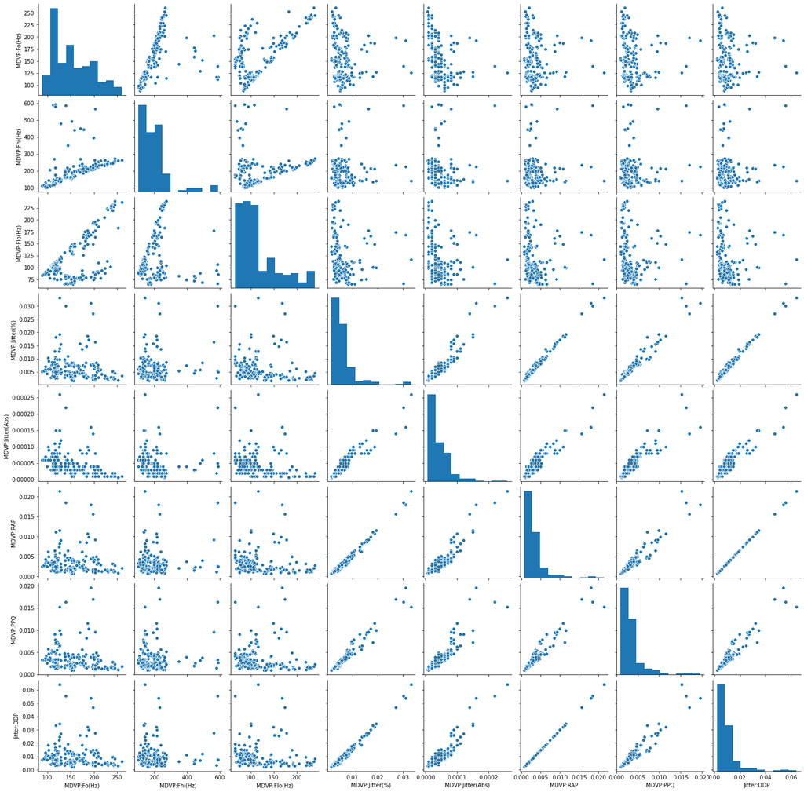

```python
# there are 22 variables in this study dataset, will investigare if some of them have a strong linear relation with some others
# if so, we can remove these variables as they will be considered as extra unusefull information, additionally, removing them
# will ease the computation process and save time.

# will show the visual relationships graphically in three steps to have a clearer image.

sns.pairplot(data.iloc[:,1:9])
```

```python
# find the correltion index between the first 8 variables
data.iloc[:,1:9].corr()
```

|  | MDVP:Fo(Hz) | MDVP:Fhi(Hz) | MDVP:Flo(Hz) | MDVP:Jitter(%) | MDVP:Jitter(Abs) | MDVP:RAP | MDVP:PPQ | Jitter:DDP |
| --- | --- | --- | --- | --- | --- | --- | --- | --- |
| MDVP:Fo(Hz) | 1.00 | 0.40 | 0.60 | -0.12 | -0.38 | -0.08 | -0.11 | -0.08 |
| MDVP:Fhi(Hz) | 0.40 | 1.00 | 0.08 | 0.10 | -0.03 | 0.10 | 0.09 | 0.10 |
| MDVP:Flo(Hz) | 0.60 | 0.08 | 1.00 | -0.14 | -0.28 | -0.10 | -0.10 | -0.10 |
| MDVP:Jitter(%) | -0.12 | 0.10 | -0.14 | 1.00 | 0.94 | 0.99 | 0.97 | 0.99 |
| MDVP:Jitter(Abs) | -0.38 | -0.03 | -0.28 | 0.94 | 1.00 | 0.92 | 0.90 | 0.92 |
| MDVP:RAP | -0.08 | 0.10 | -0.10 | 0.99 | 0.92 | 1.00 | 0.96 | 1.00 |
| MDVP:PPQ | -0.11 | 0.09 | -0.10 | 0.97 | 0.90 | 0.96 | 1.00 | 0.96 |
| Jitter:DDP | -0.08 | 0.10 | -0.10 | 0.99 | 0.92 | 1.00 | 0.96 | 1.00 |

as we can see from the pairplot and correlation table, variables MDVP:Jitter(%), MDVP:Jitter(Abs),MDVP:RAP,MDVP:PPQ, Jitter:DDP, has very strong linear relationship with each other. so we can drop 4 of them and keep one only without loosing significant information. we can see Jitter(%) has the strongest correlation with each other variable, will keep it and drop the rest.

```python
data.drop(['MDVP:Jitter(Abs)','MDVP:RAP','MDVP:PPQ','Jitter:DDP'],axis=1,inplace=True)
data.head()
```

|  | name | MDVP:Fo(Hz) | MDVP:Fhi(Hz) | MDVP:Flo(Hz) | MDVP:Jitter(%) | MDVP:Shimmer | MDVP:Shimmer(dB) | Shimmer:APQ3 | Shimmer:APQ5 | MDVP:APQ | Shimmer:DDA | NHR | HNR | status | RPDE | DFA | spread1 | spread2 | D2 | PPE |
| --- | --- | --- | --- | --- | --- | --- | --- | --- | --- | --- | --- | --- | --- | --- | --- | --- | --- | --- | --- | --- |
| 0 | phon_R01_S01_1 | 119.99 | 157.30 | 75.00 | 0.01 | 0.04 | 0.43 | 0.02 | 0.03 | 0.03 | 0.07 | 0.02 | 21.03 | 1 | 0.41 | 0.82 | -4.81 | 0.27 | 2.30 | 0.28 |
| 1 | phon_R01_S01_2 | 122.40 | 148.65 | 113.82 | 0.01 | 0.06 | 0.63 | 0.03 | 0.05 | 0.04 | 0.09 | 0.02 | 19.09 | 1 | 0.46 | 0.82 | -4.08 | 0.34 | 2.49 | 0.37 |
| 2 | phon_R01_S01_3 | 116.68 | 131.11 | 111.56 | 0.01 | 0.05 | 0.48 | 0.03 | 0.04 | 0.04 | 0.08 | 0.01 | 20.65 | 1 | 0.43 | 0.83 | -4.44 | 0.31 | 2.34 | 0.33 |
| 3 | phon_R01_S01_4 | 116.68 | 137.87 | 111.37 | 0.01 | 0.05 | 0.52 | 0.03 | 0.04 | 0.04 | 0.09 | 0.01 | 20.64 | 1 | 0.43 | 0.82 | -4.12 | 0.33 | 2.41 | 0.37 |
| 4 | phon_R01_S01_5 | 116.01 | 141.78 | 110.66 | 0.01 | 0.06 | 0.58 | 0.03 | 0.05 | 0.04 | 0.10 | 0.02 | 19.65 | 1 | 0.42 | 0.82 | -3.75 | 0.23 | 2.33 | 0.41 |

```python
data.shape
```

```
(195, 20)
```

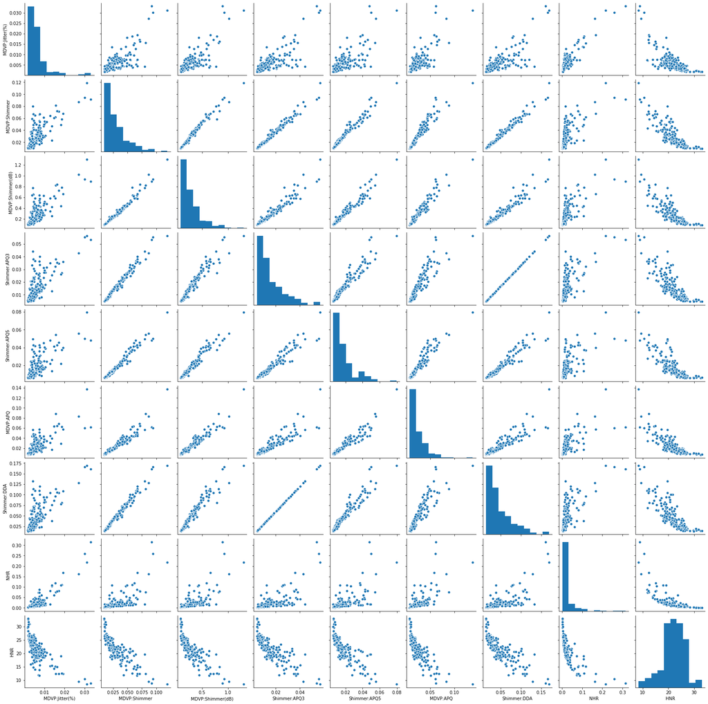

```python
# now will show the next 9 variables

sns.pairplot(data.iloc[:,4:13])
```

```python
# find the correltion index between these 9 variables
data.iloc[:,4:13].corr()
```

|  | MDVP:Jitter(%) | MDVP:Shimmer | MDVP:Shimmer(dB) | Shimmer:APQ3 | Shimmer:APQ5 | MDVP:APQ | Shimmer:DDA | NHR | HNR |
| --- | --- | --- | --- | --- | --- | --- | --- | --- | --- |
| MDVP:Jitter(%) | 1.00 | 0.77 | 0.80 | 0.75 | 0.73 | 0.76 | 0.75 | 0.91 | -0.73 |
| MDVP:Shimmer | 0.77 | 1.00 | 0.99 | 0.99 | 0.98 | 0.95 | 0.99 | 0.72 | -0.84 |
| MDVP:Shimmer(dB) | 0.80 | 0.99 | 1.00 | 0.96 | 0.97 | 0.96 | 0.96 | 0.74 | -0.83 |
| Shimmer:APQ3 | 0.75 | 0.99 | 0.96 | 1.00 | 0.96 | 0.90 | 1.00 | 0.72 | -0.83 |
| Shimmer:APQ5 | 0.73 | 0.98 | 0.97 | 0.96 | 1.00 | 0.95 | 0.96 | 0.66 | -0.81 |
| MDVP:APQ | 0.76 | 0.95 | 0.96 | 0.90 | 0.95 | 1.00 | 0.90 | 0.69 | -0.80 |
| Shimmer:DDA | 0.75 | 0.99 | 0.96 | 1.00 | 0.96 | 0.90 | 1.00 | 0.72 | -0.83 |
| NHR | 0.91 | 0.72 | 0.74 | 0.72 | 0.66 | 0.69 | 0.72 | 1.00 | -0.71 |
| HNR | -0.73 | -0.84 | -0.83 | -0.83 | -0.81 | -0.80 | -0.83 | -0.71 | 1.00 |

as we can see from the pairplot and correlation table, variables MDVP:Shimmer MDVP:Shimmer(dB) Shimmer:APQ3 Shimmer:APQ5 MDVP:APQ Shimmer:DDA, have very strong linear relationship with each other.

so we can drop 5 of them and keep one only without loosing significant information. we can see MDVP:Shimmer has the strongest correlation with each other variable, will keep it and drop the rest.

```python
data.drop(['MDVP:Shimmer(dB)','Shimmer:APQ3','Shimmer:APQ5','MDVP:APQ','Shimmer:DDA'],axis=1,inplace=True)
data.shape
```

```
(195, 15)
```

```python
data.head()
```

|  | name | MDVP:Fo(Hz) | MDVP:Fhi(Hz) | MDVP:Flo(Hz) | MDVP:Jitter(%) | MDVP:Shimmer | NHR | HNR | status | RPDE | DFA | spread1 | spread2 | D2 | PPE |
| --- | --- | --- | --- | --- | --- | --- | --- | --- | --- | --- | --- | --- | --- | --- | --- |
| 0 | phon_R01_S01_1 | 119.99 | 157.30 | 75.00 | 0.01 | 0.04 | 0.02 | 21.03 | 1 | 0.41 | 0.82 | -4.81 | 0.27 | 2.30 | 0.28 |
| 1 | phon_R01_S01_2 | 122.40 | 148.65 | 113.82 | 0.01 | 0.06 | 0.02 | 19.09 | 1 | 0.46 | 0.82 | -4.08 | 0.34 | 2.49 | 0.37 |
| 2 | phon_R01_S01_3 | 116.68 | 131.11 | 111.56 | 0.01 | 0.05 | 0.01 | 20.65 | 1 | 0.43 | 0.83 | -4.44 | 0.31 | 2.34 | 0.33 |
| 3 | phon_R01_S01_4 | 116.68 | 137.87 | 111.37 | 0.01 | 0.05 | 0.01 | 20.64 | 1 | 0.43 | 0.82 | -4.12 | 0.33 | 2.41 | 0.37 |
| 4 | phon_R01_S01_5 | 116.01 | 141.78 | 110.66 | 0.01 | 0.06 | 0.02 | 19.65 | 1 | 0.42 | 0.82 | -3.75 | 0.23 | 2.33 | 0.41 |

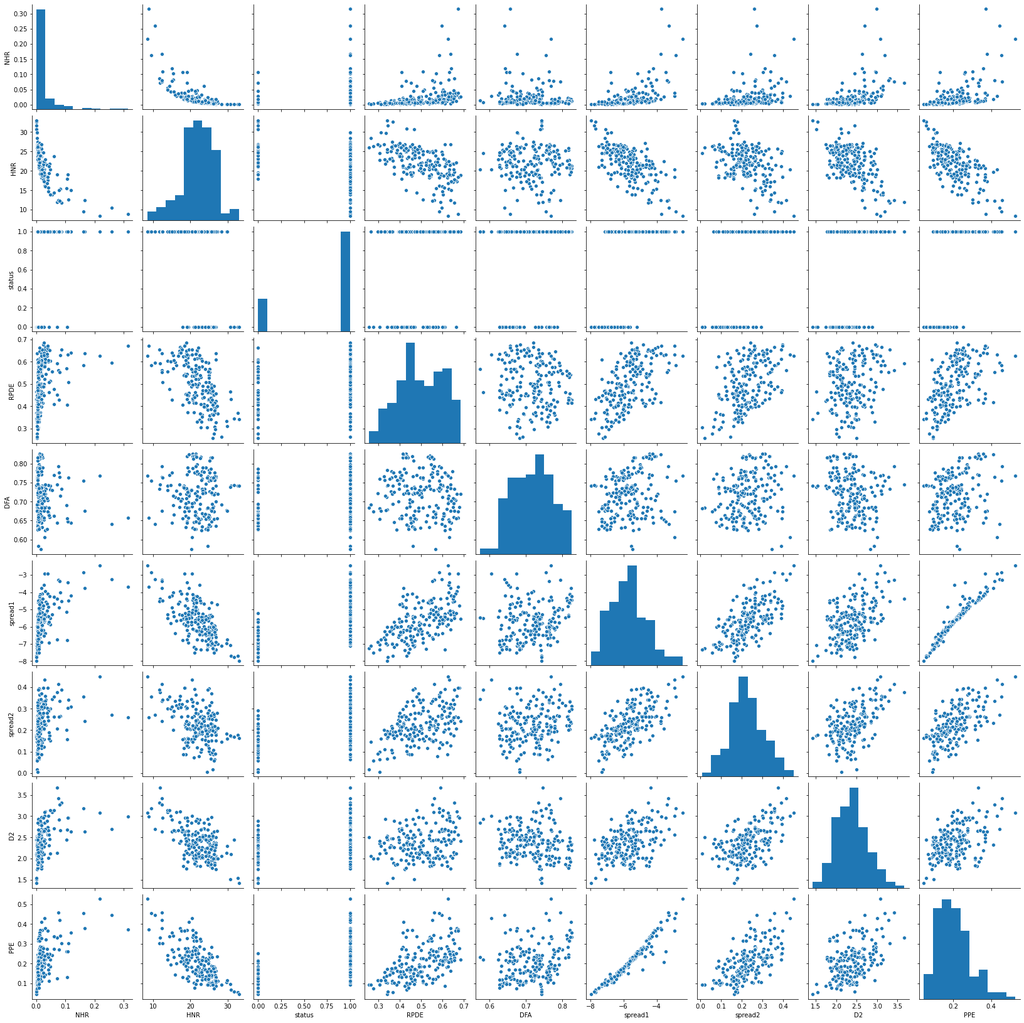

```python
sns.pairplot(data.iloc[:,6:15])
```

```python
# find the correltion index between the last 8 variables
data.iloc[:,6:15].corr()
```

|  | NHR | HNR | status | RPDE | DFA | spread1 | spread2 | D2 | PPE |
| --- | --- | --- | --- | --- | --- | --- | --- | --- | --- |
| NHR | 1.00 | -0.71 | 0.19 | 0.37 | -0.13 | 0.54 | 0.32 | 0.47 | 0.55 |
| HNR | -0.71 | 1.00 | -0.36 | -0.60 | -0.01 | -0.67 | -0.43 | -0.60 | -0.69 |
| status | 0.19 | -0.36 | 1.00 | 0.31 | 0.23 | 0.56 | 0.45 | 0.34 | 0.53 |
| RPDE | 0.37 | -0.60 | 0.31 | 1.00 | -0.11 | 0.59 | 0.48 | 0.24 | 0.55 |
| DFA | -0.13 | -0.01 | 0.23 | -0.11 | 1.00 | 0.20 | 0.17 | -0.17 | 0.27 |
| spread1 | 0.54 | -0.67 | 0.56 | 0.59 | 0.20 | 1.00 | 0.65 | 0.50 | 0.96 |
| spread2 | 0.32 | -0.43 | 0.45 | 0.48 | 0.17 | 0.65 | 1.00 | 0.52 | 0.64 |
| D2 | 0.47 | -0.60 | 0.34 | 0.24 | -0.17 | 0.50 | 0.52 | 1.00 | 0.48 |
| PPE | 0.55 | -0.69 | 0.53 | 0.55 | 0.27 | 0.96 | 0.64 | 0.48 | 1.00 |

as we can see from the pairplot and correlation table, variables spread1 and PPE , have very strong linear relationship with each other.

so we can drop one of them and keep the other without loosing significant information. we can see spread1 has the stronger relation with the target 'status', so will keep it and drop PPE. also will drop column 'name' as it has no effect on the study case.

```python
data.drop(['PPE','name'],axis=1,inplace=True)
data.shape
```

```
(195, 13)
```

```python
data.head()
```

|  | MDVP:Fo(Hz) | MDVP:Fhi(Hz) | MDVP:Flo(Hz) | MDVP:Jitter(%) | MDVP:Shimmer | NHR | HNR | status | RPDE | DFA | spread1 | spread2 | D2 |
| --- | --- | --- | --- | --- | --- | --- | --- | --- | --- | --- | --- | --- | --- |
| 0 | 119.99 | 157.30 | 75.00 | 0.01 | 0.04 | 0.02 | 21.03 | 1 | 0.41 | 0.82 | -4.81 | 0.27 | 2.30 |
| 1 | 122.40 | 148.65 | 113.82 | 0.01 | 0.06 | 0.02 | 19.09 | 1 | 0.46 | 0.82 | -4.08 | 0.34 | 2.49 |
| 2 | 116.68 | 131.11 | 111.56 | 0.01 | 0.05 | 0.01 | 20.65 | 1 | 0.43 | 0.83 | -4.44 | 0.31 | 2.34 |
| 3 | 116.68 | 137.87 | 111.37 | 0.01 | 0.05 | 0.01 | 20.64 | 1 | 0.43 | 0.82 | -4.12 | 0.33 | 2.41 |
| 4 | 116.01 | 141.78 | 110.66 | 0.01 | 0.06 | 0.02 | 19.65 | 1 | 0.42 | 0.82 | -3.75 | 0.23 | 2.33 |

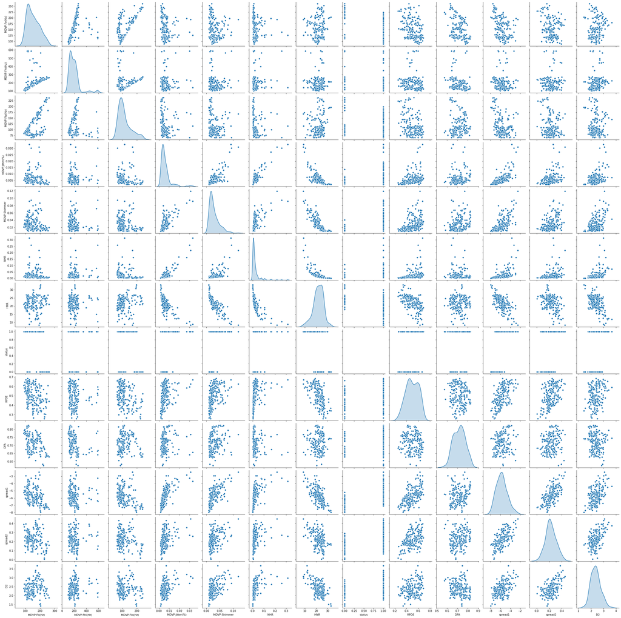

```python
sns.pairplot(data,diag_kind='kde')
```

# Univariate & Bivariate analysis with Data Visualization.

# 0- MDVP:Fo(Hz)

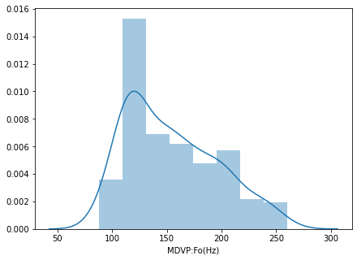

```python
plt.figure(figsize = (7,5))
sns.distplot(data['MDVP:Fo(Hz)'])
```

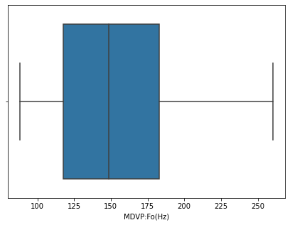

```python
plt.figure(figsize = (7,5))
sns.boxplot(data['MDVP:Fo(Hz)'])
```

the plots show a slight skewness to right, but we can't see any outliers.

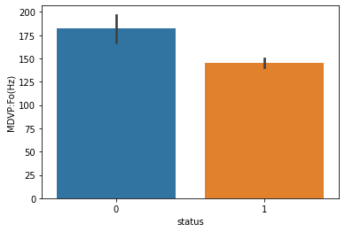

```python
sns.barplot(x='status',y='MDVP:Fo(Hz)',data=data)
plt.show()
```

```python
data[data['MDVP:Fo(Hz)']<110]['status'].value_counts(normalize=True)
```

```
1   1.00
Name: status, dtype: float64
```

```python
data[data['MDVP:Fo(Hz)']>110]['status'].value_counts(normalize=True)
```

```
1   0.73
0   0.27
Name: status, dtype: float64
```

```python
data[data['MDVP:Fo(Hz)']>150]['status'].value_counts(normalize=True)
```

```
1   0.68
0   0.32
Name: status, dtype: float64
```

```python
data[data['MDVP:Fo(Hz)']>224]['status'].value_counts(normalize=True)
```

```
0   1.00
Name: status, dtype: float64
```

as we see from the plot and codes above, the Fo variable is a very important indicator of wheather the subject person is healthy or not, as we noticed, all the cases with Fo frequencies below 110 hz are diagnozed as Parkinson case. when the Fo increases, the percentage of Parkinson cases decrease.

# 1 - MDVP:Fhi(Hz)

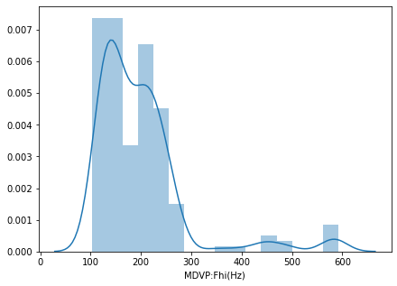

```python
plt.figure(figsize = (7,5))
sns.distplot(data['MDVP:Fhi(Hz)'])
```

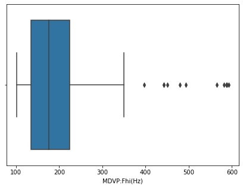

```python
# Scanning for the outliers by boxplot graph

plt.figure(figsize = (7,5))
sns.boxplot(data['MDVP:Fhi(Hz)'])
```

we can see some some values out of the upper whisker range.

```python
# find the outliers values and locations

Q1 = data['MDVP:Fhi(Hz)'].quantile(0.25)
Q3 = data['MDVP:Fhi(Hz)'].quantile(0.75)
IQR = Q3 - Q1
print('Q1=',Q1,',','Q3=',Q3,',','IQR=',IQR)
ol=data['MDVP:Fhi(Hz)'].iloc[np.where((data['MDVP:Fhi(Hz)']<(Q1 - 1.5 * IQR))|(data['MDVP:Fhi(Hz)']>(Q3 + 1.5 * IQR)))].sort_values()
print('outliers Rows:','\n',ol)
```

```
Q1= 134.8625 , Q3= 224.2055 , IQR= 89.34299999999999
outliers Rows:
 193   396.96
116   442.56
118   442.82
117   450.25
120   479.70
115   492.89
149   565.74
187   581.29
102   586.57
73    588.52
186   592.03
Name: MDVP:Fhi(Hz), dtype: float64
```

```python
# Dealing with outliers by replacing with the IQR Score

data1 = data.copy() # keep the original dataset intact

#Replace every outlier on the upper side by the upper whisker
for i in np.where(data1['MDVP:Fhi(Hz)'] > Q3 + 1.5 * IQR):

    whisker  = Q3 + 1.5 * IQR
    data1['MDVP:Fhi(Hz)'].iloc[i] = whisker




# Replace every outlier on the lower side by the lower whisker
#for i in np.where(data1['MDVP:Fhi(Hz)'] < Q1 - 1.5 * IQR):

#    whisker  = Q1 - 1.5 * IQR
#    data1['MDVP:Fhi(Hz)'].iloc[i] = whisker
```

```python
data1.iloc[[193,116,118,117,120,115,149,187,102,73,186],1]
```

```
193   358.22
116   358.22
118   358.22
117   358.22
120   358.22
115   358.22
149   358.22
187   358.22
102   358.22
73    358.22
186   358.22
Name: MDVP:Fhi(Hz), dtype: float64
```

```python
data1
```

|  | MDVP:Fo(Hz) | MDVP:Fhi(Hz) | MDVP:Flo(Hz) | MDVP:Jitter(%) | MDVP:Shimmer | NHR | HNR | status | RPDE | DFA | spread1 | spread2 | D2 |
| --- | --- | --- | --- | --- | --- | --- | --- | --- | --- | --- | --- | --- | --- |
| 0 | 119.99 | 157.30 | 75.00 | 0.01 | 0.04 | 0.02 | 21.03 | 1 | 0.41 | 0.82 | -4.81 | 0.27 | 2.30 |
| 1 | 122.40 | 148.65 | 113.82 | 0.01 | 0.06 | 0.02 | 19.09 | 1 | 0.46 | 0.82 | -4.08 | 0.34 | 2.49 |
| 2 | 116.68 | 131.11 | 111.56 | 0.01 | 0.05 | 0.01 | 20.65 | 1 | 0.43 | 0.83 | -4.44 | 0.31 | 2.34 |
| 3 | 116.68 | 137.87 | 111.37 | 0.01 | 0.05 | 0.01 | 20.64 | 1 | 0.43 | 0.82 | -4.12 | 0.33 | 2.41 |
| 4 | 116.01 | 141.78 | 110.66 | 0.01 | 0.06 | 0.02 | 19.65 | 1 | 0.42 | 0.82 | -3.75 | 0.23 | 2.33 |
| ... | ... | ... | ... | ... | ... | ... | ... | ... | ... | ... | ... | ... | ... |
| 190 | 174.19 | 230.98 | 94.26 | 0.00 | 0.04 | 0.03 | 19.52 | 0 | 0.45 | 0.66 | -6.54 | 0.12 | 2.66 |
| 191 | 209.52 | 253.02 | 89.49 | 0.01 | 0.03 | 0.02 | 19.15 | 0 | 0.43 | 0.68 | -6.20 | 0.13 | 2.78 |
| 192 | 174.69 | 240.00 | 74.29 | 0.01 | 0.02 | 0.11 | 17.88 | 0 | 0.41 | 0.66 | -6.79 | 0.16 | 2.68 |
| 193 | 198.76 | 358.22 | 74.90 | 0.01 | 0.02 | 0.07 | 19.02 | 0 | 0.45 | 0.64 | -6.74 | 0.21 | 2.14 |
| 194 | 214.29 | 260.28 | 77.97 | 0.01 | 0.02 | 0.04 | 21.21 | 0 | 0.46 | 0.66 | -5.72 | 0.19 | 2.56 |

195 rows × 13 columns

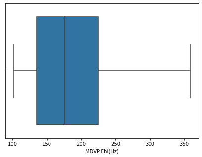

```python
# Checking out again for the outliers

plt.figure(figsize = (7,5))
sns.boxplot(data1['MDVP:Fhi(Hz)'])
```

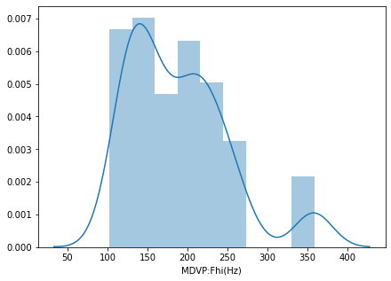

```python
plt.figure(figsize = (7,5))
sns.distplot(data1['MDVP:Fhi(Hz)'])
```

As we can the outliers are reduced to the minimum.

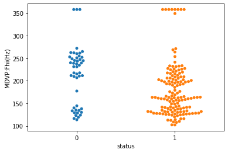

```python
sns.swarmplot(x='status',y='MDVP:Fhi(Hz)',data=data1)
plt.show()
```

```python
data[data['MDVP:Fhi(Hz)']<113]['status'].value_counts(normalize=True)
```

```
1   1.00
Name: status, dtype: float64
```

```python
data[data['MDVP:Fhi(Hz)']>113]['status'].value_counts(normalize=True)
```

```
1   0.74
0   0.26
Name: status, dtype: float64
```

```python
data[data['MDVP:Fhi(Hz)']>170]['status'].value_counts(normalize=True)
```

```
1   0.66
0   0.34
Name: status, dtype: float64
```

```python
data[data['MDVP:Fhi(Hz)']>200]['status'].value_counts(normalize=True)
```

```
1   0.58
0   0.42
Name: status, dtype: float64
```

as we see from the plot and codes above, the Fi variable is a very important indicator of wheather the subject person is healthy or not, as we noticed, all the cases with Fi frequencies below 113 hz are diagnozed as Parkinson case. when the Fo increases, the percentage of Parkinson cases decrease.

# 2- MDVP:Flo(Hz)

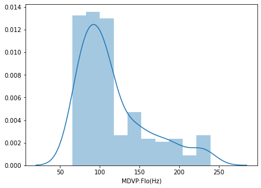

```python
# check out for the natural distribution of the variable

plt.figure(figsize = (7,5))
sns.distplot(data1['MDVP:Flo(Hz)'])
```

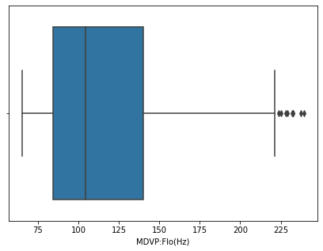

```python
# Scanning for the outliers by boxplot graph

plt.figure(figsize = (7,5))
sns.boxplot(data1['MDVP:Flo(Hz)'])
```

we can see there are some outliers byeond the upper whisker

```python
# find the outliers values and locations

Q1 = data1['MDVP:Flo(Hz)'].quantile(0.25)
Q3 = data1['MDVP:Flo(Hz)'].quantile(0.75)
IQR = Q3 - Q1
print('Q1=',Q1,',','Q3=',Q3,',','IQR=',IQR)
ol=data1['MDVP:Flo(Hz)'].iloc[np.where((data1['MDVP:Flo(Hz)']<(Q1 - 1.5 * IQR))|(data1['MDVP:Flo(Hz)']>(Q3 + 1.5 * IQR)))].sort_values()
print('outliers Rows:','\n',ol)
```

```
Q1= 84.291 , Q3= 140.01850000000002 , IQR= 55.72750000000002
outliers Rows:
 63    223.63
42    225.23
45    227.91
166   229.26
46    231.85
44    232.44
43    232.48
167   237.30
170   239.17
Name: MDVP:Flo(Hz), dtype: float64
```

```python
# Dealing with the 9 outliers by replacing with the IQR Score

data2 = data1.copy() # keep the original dataset intact

#Replace every outlier on the upper side by the upper whisker
for i in np.where(data2['MDVP:Flo(Hz)'] > Q3 + 1.5 * IQR):

    whisker  = Q3 + 1.5 * IQR
    data2['MDVP:Flo(Hz)'].iloc[i] = whisker
```

```python
data2.iloc[[63,42,45,166,46,44,43,167,170],2]
```

```
63    223.61
42    223.61
45    223.61
166   223.61
46    223.61
44    223.61
43    223.61
167   223.61
170   223.61
Name: MDVP:Flo(Hz), dtype: float64
```

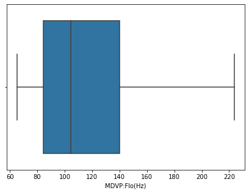

```python
# Checking out again for the outliers

plt.figure(figsize = (7,5))
sns.boxplot(data2['MDVP:Flo(Hz)'])
```

can the outliers are reduced to the minimum.

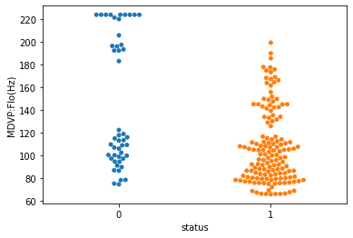

```python
sns.swarmplot(x='status',y='MDVP:Flo(Hz)',data=data2)
plt.show()
```

as we can see from the plot, the more 'Flo(Hz)' increases, the Parkinsons's cases decreases.

```python
data2.columns
```

```
Index(['MDVP:Fo(Hz)', 'MDVP:Fhi(Hz)', 'MDVP:Flo(Hz)', 'MDVP:Jitter(%)',
       'MDVP:Shimmer', 'NHR', 'HNR', 'status', 'RPDE', 'DFA', 'spread1',
       'spread2', 'D2'],
      dtype='object')
```

# 3- MDVP:Jitter(%)

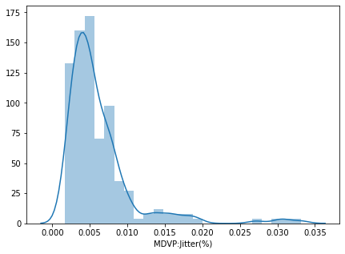

```python
# check out for the natural distribution of the variable

plt.figure(figsize = (7,5))
sns.distplot(data2['MDVP:Jitter(%)'])
```

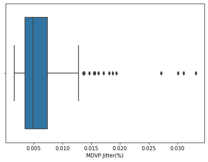

```python
# Scanning for the outliers by boxplot graph

plt.figure(figsize = (7,5))
sns.boxplot(data2['MDVP:Jitter(%)'])
```

we can see there are many outliers byeond the upper whisker

```python
# find the outliers values and locations

Q1 = data2['MDVP:Jitter(%)'].quantile(0.25)
Q3 = data2['MDVP:Jitter(%)'].quantile(0.75)
IQR = Q3 - Q1
print('Q1=',Q1,',','Q3=',Q3,',','IQR=',IQR)
rows=np.where((data2['MDVP:Jitter(%)']<(Q1 - 1.5 * IQR))|(data2['MDVP:Jitter(%)']>(Q3 + 1.5 * IQR)))
ol=data2['MDVP:Jitter(%)'].iloc[rows].sort_values()
print('outliers Rows:','\n',ol)
```

```
Q1= 0.00346 , Q3= 0.007365 , IQR= 0.003905
outliers Rows:
 192   0.01
98    0.01
147   0.01
101   0.02
146   0.02
149   0.02
148   0.02
157   0.02
150   0.02
99    0.02
152   0.03
102   0.03
151   0.03
100   0.03
Name: MDVP:Jitter(%), dtype: float64
```

```python
# Dealing with the 14 outliers by replacing with the IQR Score

data3 = data2.copy() # keep the original dataset intact

#Replace every outlier on the upper side by the upper whisker
for i in np.where(data3['MDVP:Jitter(%)'] > Q3 + 1.5 * IQR):

    whisker  = Q3 + 1.5 * IQR
    data3['MDVP:Jitter(%)'].iloc[i] = whisker

data3.iloc[rows]
```

|  | MDVP:Fo(Hz) | MDVP:Fhi(Hz) | MDVP:Flo(Hz) | MDVP:Jitter(%) | MDVP:Shimmer | NHR | HNR | status | RPDE | DFA | spread1 | spread2 | D2 |
| --- | --- | --- | --- | --- | --- | --- | --- | --- | --- | --- | --- | --- | --- |
| 98 | 125.79 | 140.56 | 96.21 | 0.01 | 0.05 | 0.10 | 15.43 | 1 | 0.57 | 0.69 | -5.16 | 0.20 | 2.44 |
| 99 | 126.51 | 141.76 | 99.77 | 0.01 | 0.07 | 0.17 | 12.44 | 1 | 0.64 | 0.67 | -3.76 | 0.24 | 2.63 |
| 100 | 125.64 | 141.07 | 116.35 | 0.01 | 0.09 | 0.31 | 8.87 | 1 | 0.67 | 0.66 | -3.70 | 0.26 | 2.99 |
| 101 | 128.45 | 150.45 | 75.63 | 0.01 | 0.06 | 0.12 | 15.06 | 1 | 0.64 | 0.64 | -4.20 | 0.31 | 2.64 |
| 102 | 139.22 | 358.22 | 66.16 | 0.01 | 0.09 | 0.26 | 10.49 | 1 | 0.60 | 0.64 | -3.27 | 0.27 | 2.69 |
| 146 | 169.77 | 191.76 | 151.45 | 0.01 | 0.08 | 0.08 | 12.36 | 1 | 0.56 | 0.79 | -3.30 | 0.41 | 3.41 |
| 147 | 183.52 | 216.81 | 161.34 | 0.01 | 0.06 | 0.06 | 14.37 | 1 | 0.48 | 0.77 | -4.28 | 0.36 | 3.14 |
| 148 | 188.62 | 216.30 | 165.98 | 0.01 | 0.07 | 0.08 | 12.30 | 1 | 0.55 | 0.76 | -3.38 | 0.34 | 3.27 |
| 149 | 202.63 | 358.22 | 177.26 | 0.01 | 0.07 | 0.08 | 14.99 | 1 | 0.43 | 0.78 | -4.89 | 0.26 | 2.91 |
| 150 | 186.69 | 211.96 | 149.44 | 0.01 | 0.06 | 0.11 | 12.53 | 1 | 0.51 | 0.76 | -4.48 | 0.34 | 2.96 |
| 151 | 192.82 | 224.43 | 168.79 | 0.01 | 0.12 | 0.22 | 8.44 | 1 | 0.63 | 0.77 | -2.43 | 0.45 | 3.08 |
| 152 | 198.12 | 233.10 | 174.48 | 0.01 | 0.09 | 0.16 | 9.45 | 1 | 0.58 | 0.75 | -2.84 | 0.36 | 3.18 |
| 157 | 117.96 | 134.21 | 100.76 | 0.01 | 0.05 | 0.11 | 19.07 | 1 | 0.63 | 0.65 | -3.44 | 0.30 | 2.96 |
| 192 | 174.69 | 240.00 | 74.29 | 0.01 | 0.02 | 0.11 | 17.88 | 0 | 0.41 | 0.66 | -6.79 | 0.16 | 2.68 |

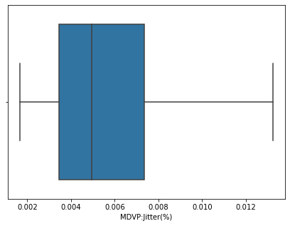

```python
# Checking out again for the outliers

plt.figure(figsize = (7,5))
sns.boxplot(data3['MDVP:Jitter(%)'])
```

can the outliers are reduced to the minimum.

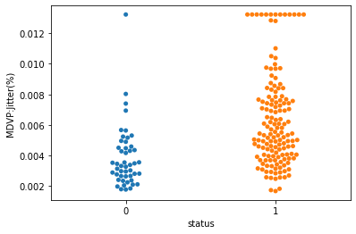

```python
sns.swarmplot(x='status',y='MDVP:Jitter(%)',data=data3)
plt.show()
```

as we can see from the plot, the more 'MDVP:Jitter(%))' increases, the Parkinsons's cases increases.

the attribute has strong relation with Parkinson's disease.

```python
data3.columns
```

```
Index(['MDVP:Fo(Hz)', 'MDVP:Fhi(Hz)', 'MDVP:Flo(Hz)', 'MDVP:Jitter(%)',
       'MDVP:Shimmer', 'NHR', 'HNR', 'status', 'RPDE', 'DFA', 'spread1',
       'spread2', 'D2'],
      dtype='object')
```

# 4- MDVP:Shimmer

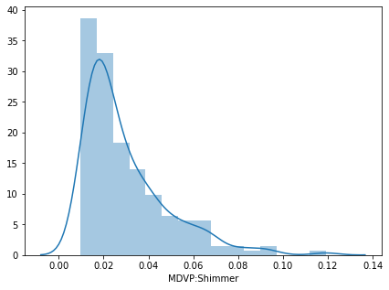

```python
# check out for the natural distribution of the variable

plt.figure(figsize = (7,5))
sns.distplot(data3['MDVP:Shimmer'])
```

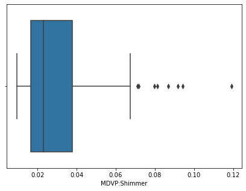

```python
# Scanning for the outliers by boxplot graph

plt.figure(figsize = (7,5))
sns.boxplot(data3['MDVP:Shimmer'])
```

we can see there are some outliers byeond the upper whisker

```python
# find the outliers values and locations

Q1 = data3['MDVP:Shimmer'].quantile(0.25)
Q3 = data3['MDVP:Shimmer'].quantile(0.75)
IQR = Q3 - Q1
print('Q1=',Q1,',','Q3=',Q3,',','IQR=',IQR)
rows=np.where((data3['MDVP:Shimmer']<(Q1 - 1.5 * IQR))|(data3['MDVP:Shimmer']>(Q3 + 1.5 * IQR)))
outlayers=data3['MDVP:Shimmer'].iloc[rows].sort_values()
print('outliers Rows:','\n',outlayers)
```

```
Q1= 0.016505 , Q3= 0.037885 , IQR= 0.021380000000000003
outliers Rows:
 148   0.07
149   0.07
91    0.08
146   0.08
152   0.09
100   0.09
102   0.09
151   0.12
Name: MDVP:Shimmer, dtype: float64
```

```python
# Dealing with the 8 outliers by replacing with the IQR Score

data4 = data3.copy() # keep the original dataset intact

#Replace every outlier on the upper side by the upper whisker
for i in np.where(data4['MDVP:Shimmer'] > Q3 + 1.5 * IQR):

    whisker  = Q3 + 1.5 * IQR
    data4['MDVP:Shimmer'].iloc[i] = whisker

data4.iloc[rows]
```

|  | MDVP:Fo(Hz) | MDVP:Fhi(Hz) | MDVP:Flo(Hz) | MDVP:Jitter(%) | MDVP:Shimmer | NHR | HNR | status | RPDE | DFA | spread1 | spread2 | D2 |
| --- | --- | --- | --- | --- | --- | --- | --- | --- | --- | --- | --- | --- | --- |
| 91 | 151.96 | 163.34 | 147.23 | 0.00 | 0.07 | 0.02 | 19.66 | 1 | 0.50 | 0.71 | -6.41 | 0.21 | 2.34 |
| 100 | 125.64 | 141.07 | 116.35 | 0.01 | 0.07 | 0.31 | 8.87 | 1 | 0.67 | 0.66 | -3.70 | 0.26 | 2.99 |
| 102 | 139.22 | 358.22 | 66.16 | 0.01 | 0.07 | 0.26 | 10.49 | 1 | 0.60 | 0.64 | -3.27 | 0.27 | 2.69 |
| 146 | 169.77 | 191.76 | 151.45 | 0.01 | 0.07 | 0.08 | 12.36 | 1 | 0.56 | 0.79 | -3.30 | 0.41 | 3.41 |
| 148 | 188.62 | 216.30 | 165.98 | 0.01 | 0.07 | 0.08 | 12.30 | 1 | 0.55 | 0.76 | -3.38 | 0.34 | 3.27 |
| 149 | 202.63 | 358.22 | 177.26 | 0.01 | 0.07 | 0.08 | 14.99 | 1 | 0.43 | 0.78 | -4.89 | 0.26 | 2.91 |
| 151 | 192.82 | 224.43 | 168.79 | 0.01 | 0.07 | 0.22 | 8.44 | 1 | 0.63 | 0.77 | -2.43 | 0.45 | 3.08 |
| 152 | 198.12 | 233.10 | 174.48 | 0.01 | 0.07 | 0.16 | 9.45 | 1 | 0.58 | 0.75 | -2.84 | 0.36 | 3.18 |

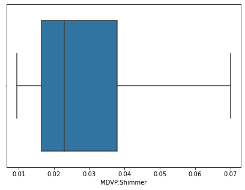

```python
# Checking out again for the outliers

plt.figure(figsize = (7,5))
sns.boxplot(data4['MDVP:Shimmer'])
```

can the outliers are reduced to the minimum.

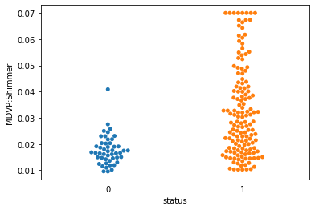

```python
sns.swarmplot(x='status',y='MDVP:Shimmer',data=data4)
plt.show()
```

as we can see from the plot, the more 'MDVP:Shimmer' increases, the Parkinsons's cases increases.

the attribute has very strongrelation with Parkinson's disease.

```python
data3.columns
```

```
Index(['MDVP:Fo(Hz)', 'MDVP:Fhi(Hz)', 'MDVP:Flo(Hz)', 'MDVP:Jitter(%)',
       'MDVP:Shimmer', 'NHR', 'HNR', 'status', 'RPDE', 'DFA', 'spread1',
       'spread2', 'D2'],
      dtype='object')
```

# 5- NHR

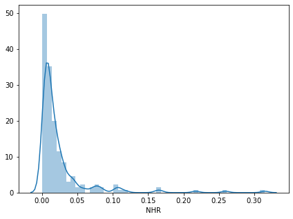

```python
# check out for the natural distribution of the variable

plt.figure(figsize = (7,5))
sns.distplot(data4['NHR'])
```

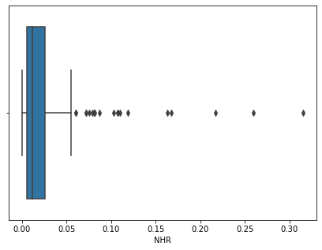

```python
# Scanning for the outliers by boxplot graph

plt.figure(figsize = (7,5))
sns.boxplot(data4['NHR'])
```

we can see there are many outliers byeond the upper whisker

```python
# find the outliers values and locations

Q1 = data4['NHR'].quantile(0.25)
Q3 = data4['NHR'].quantile(0.75)
IQR = Q3 - Q1
print('Q1=',Q1,',','Q3=',Q3,',','IQR=',IQR)
rows=np.where((data['NHR']<(Q1 - 1.5 * IQR))|(data4['NHR']>(Q3 + 1.5 * IQR)))
outlayers=data4['NHR'].iloc[rows].sort_values()
print('outliers Rows:','\n',outlayers)
```

```
Q1= 0.005925 , Q3= 0.02564 , IQR= 0.019715
outliers Rows:
 115   0.06
147   0.06
89    0.07
193   0.07
146   0.08
149   0.08
148   0.08
97    0.08
90    0.09
98    0.10
192   0.11
157   0.11
150   0.11
101   0.12
152   0.16
99    0.17
151   0.22
102   0.26
100   0.31
Name: NHR, dtype: float64
```

```python
# Dealing with the 19 outliers by replacing with the IQR Score

data5 = data4.copy() # keep the original dataset intact

#Replace every outlier on the upper side by the upper whisker
for i in np.where(data5['NHR'] > Q3 + 1.5 * IQR):

    whisker  = Q3 + 1.5 * IQR
    data5['NHR'].iloc[i] = whisker

data5.iloc[rows]
```

|  | MDVP:Fo(Hz) | MDVP:Fhi(Hz) | MDVP:Flo(Hz) | MDVP:Jitter(%) | MDVP:Shimmer | NHR | HNR | status | RPDE | DFA | spread1 | spread2 | D2 |
| --- | --- | --- | --- | --- | --- | --- | --- | --- | --- | --- | --- | --- | --- |
| 89 | 179.71 | 225.93 | 144.88 | 0.01 | 0.04 | 0.06 | 11.87 | 1 | 0.59 | 0.75 | -4.38 | 0.38 | 3.67 |
| 90 | 166.60 | 206.01 | 78.03 | 0.01 | 0.07 | 0.06 | 11.74 | 1 | 0.65 | 0.73 | -4.51 | 0.39 | 3.32 |
| 97 | 125.04 | 143.95 | 116.19 | 0.01 | 0.04 | 0.06 | 15.34 | 1 | 0.63 | 0.71 | -4.02 | 0.27 | 2.67 |
| 98 | 125.79 | 140.56 | 96.21 | 0.01 | 0.05 | 0.06 | 15.43 | 1 | 0.57 | 0.69 | -5.16 | 0.20 | 2.44 |
| 99 | 126.51 | 141.76 | 99.77 | 0.01 | 0.07 | 0.06 | 12.44 | 1 | 0.64 | 0.67 | -3.76 | 0.24 | 2.63 |
| 100 | 125.64 | 141.07 | 116.35 | 0.01 | 0.07 | 0.06 | 8.87 | 1 | 0.67 | 0.66 | -3.70 | 0.26 | 2.99 |
| 101 | 128.45 | 150.45 | 75.63 | 0.01 | 0.06 | 0.06 | 15.06 | 1 | 0.64 | 0.64 | -4.20 | 0.31 | 2.64 |
| 102 | 139.22 | 358.22 | 66.16 | 0.01 | 0.07 | 0.06 | 10.49 | 1 | 0.60 | 0.64 | -3.27 | 0.27 | 2.69 |
| 115 | 151.87 | 358.22 | 69.08 | 0.01 | 0.02 | 0.06 | 23.69 | 1 | 0.41 | 0.66 | -4.67 | 0.26 | 2.70 |
| 146 | 169.77 | 191.76 | 151.45 | 0.01 | 0.07 | 0.06 | 12.36 | 1 | 0.56 | 0.79 | -3.30 | 0.41 | 3.41 |
| 147 | 183.52 | 216.81 | 161.34 | 0.01 | 0.06 | 0.06 | 14.37 | 1 | 0.48 | 0.77 | -4.28 | 0.36 | 3.14 |
| 148 | 188.62 | 216.30 | 165.98 | 0.01 | 0.07 | 0.06 | 12.30 | 1 | 0.55 | 0.76 | -3.38 | 0.34 | 3.27 |
| 149 | 202.63 | 358.22 | 177.26 | 0.01 | 0.07 | 0.06 | 14.99 | 1 | 0.43 | 0.78 | -4.89 | 0.26 | 2.91 |
| 150 | 186.69 | 211.96 | 149.44 | 0.01 | 0.06 | 0.06 | 12.53 | 1 | 0.51 | 0.76 | -4.48 | 0.34 | 2.96 |
| 151 | 192.82 | 224.43 | 168.79 | 0.01 | 0.07 | 0.06 | 8.44 | 1 | 0.63 | 0.77 | -2.43 | 0.45 | 3.08 |
| 152 | 198.12 | 233.10 | 174.48 | 0.01 | 0.07 | 0.06 | 9.45 | 1 | 0.58 | 0.75 | -2.84 | 0.36 | 3.18 |
| 157 | 117.96 | 134.21 | 100.76 | 0.01 | 0.05 | 0.06 | 19.07 | 1 | 0.63 | 0.65 | -3.44 | 0.30 | 2.96 |
| 192 | 174.69 | 240.00 | 74.29 | 0.01 | 0.02 | 0.06 | 17.88 | 0 | 0.41 | 0.66 | -6.79 | 0.16 | 2.68 |
| 193 | 198.76 | 358.22 | 74.90 | 0.01 | 0.02 | 0.06 | 19.02 | 0 | 0.45 | 0.64 | -6.74 | 0.21 | 2.14 |

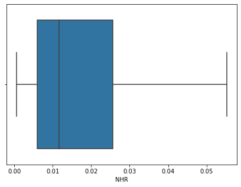

```python
# Checking out again for the outliers

plt.figure(figsize = (7,5))
sns.boxplot(data5['NHR'])
```

can the outliers are reduced to the minimum

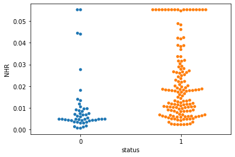

```python
sns.swarmplot(x='status',y='NHR',data=data5)
plt.show()
```

```python
data5.columns
```

```
Index(['MDVP:Fo(Hz)', 'MDVP:Fhi(Hz)', 'MDVP:Flo(Hz)', 'MDVP:Jitter(%)',
       'MDVP:Shimmer', 'NHR', 'HNR', 'status', 'RPDE', 'DFA', 'spread1',
       'spread2', 'D2'],
      dtype='object')
```